# Data Load

```python
import pandas as pd

df_Info_data = pd.read_csv('https://storage.googleapis.com/datalynn-datasets/interview-challenge/technology/Oracle_Data_Security/df_Info_data.csv')

df_Info_data['access_timestamp'] = pd.to_datetime(df_Info_data['access_timestamp'])
```

## Question 1

**Scenario:** Given the `user_id`, `resource_id`, and `access_timestamp`, one of our security mechanisms is to track the frequency and average time users spend on specific resources to identify any anomaly.

**Question:** Using the `access_frequency` and `average_access_time`, identify which users exhibit access patterns that deviate by more than 20% from their usual behavior in the past month. (View the latest date in the data as "Today")

**SQL Solution**

1. **Calculate the baseline behavior for each user:** This requires computing the average `access_frequency` and `average_access_time` for each `user_id` and `resource_id` combination over the entire dataset (ignoring the past month).
2. **Calculate behavior in the past month:** Compute the `access_frequency` and `average_access_time` for each `user_id` and `resource_id` combination in the past month.
3. **Compare the recent behavior with the baseline:** For each user-resource combination, check if the past month's access frequency or average access time deviates by more than 20% from the baseline.
4. **List the users and resources:** Identify the `user_id` and `resource_id` combinations that have anomalous behavior based on the 20% threshold.

```python
# step 1. Calculate the baseline behavior for each user:
import sqlite3

# Create a new connection and cursor
conn = sqlite3.connect(':memory:')
cursor = conn.cursor()

# Load the dataframe into sqlite3 database
df_Info_data.to_sql('Info_data', conn, if_exists='replace')

# Calculate the baseline for each user-resource combo (ignoring the past month)
baseline_query = """
SELECT user_id, resource_id,
       AVG(average_access_time) AS baseline_avg_time,
       AVG(access_frequency) AS baseline_avg_frequency
FROM Info_data
WHERE access_timestamp <= DATE('now', '-30 days')
GROUP BY user_id, resource_id;
"""

cursor.execute(baseline_query)
baseline_data = cursor.fetchall()
# baseline_data

# step 2. Calculate behavior in the past month:
past_month_query = """
SELECT user_id, resource_id,
       AVG(average_access_time) AS past_month_avg_time,
       AVG(access_frequency) AS past_month_avg_frequency
FROM Info_data
WHERE access_timestamp > DATE('now', '-30 days')
GROUP BY user_id, resource_id;
"""

cursor.execute(past_month_query)
past_month_data = cursor.fetchall()
# print(past_month_data)

# step 3. Compare recent behavior with the baseline:
comparison_query = """
WITH Baseline AS (
    SELECT user_id, resource_id,
           AVG(average_access_time) AS baseline_avg_time,
           AVG(access_frequency) AS baseline_avg_frequency
    FROM Info_data
    WHERE access_timestamp <= DATE('now', '-30 days')
    GROUP BY user_id, resource_id
),
PastMonth AS (
    SELECT user_id, resource_id,
           AVG(average_access_time) AS past_month_avg_time,
           AVG(access_frequency) AS past_month_avg_frequency
    FROM Info_data
    WHERE access_timestamp > DATE('now', '-30 days')
    GROUP BY user_id, resource_id
)

SELECT b.user_id, b.resource_id
FROM Baseline b
JOIN PastMonth p ON b.user_id = p.user_id AND b.resource_id = p.resource_id
WHERE ABS(b.baseline_avg_time - p.past_month_avg_time) / b.baseline_avg_time > 0.2
   OR ABS(b.baseline_avg_frequency - p.past_month_avg_frequency) / b.baseline_avg_frequency > 0.2;
"""

cursor.execute(comparison_query)
anomalous_users = cursor.fetchall()
anomalous_users
```

```
[('user_39', 'resource_95'),
 ('user_49', 'resource_80'),
 ('user_55', 'resource_11'),
 ('user_6', 'resource_65')]
```

**Python solution**

1. **Filter data from the past month**: Firstly, we need to filter the data to only include rows from the last month.
2. **Calculate the mean values for each user**: Once we have data from the past month, we can calculate the average `access_frequency` and `average_access_time` for each user and resource combination.
3. **Calculate the deviations for each user**: For each user and resource combination, we'll check how much their current `access_frequency` and `average_access_time` deviate from their mean values.
4. **Filter users with more than 20% deviation**: Finally, based on the deviations computed in the previous step, we'll identify the users who exhibit access patterns that deviate by more than 20% from their average behavior in the past month.

```
     user_id  resource_id  freq_deviation  time_deviation
46   user_39  resource_95        0.181818        0.609562
127  user_49  resource_80        0.655172        1.467337
172   user_6  resource_65        3.000000        1.757426
824  user_55  resource_11        0.764706       20.200000
```

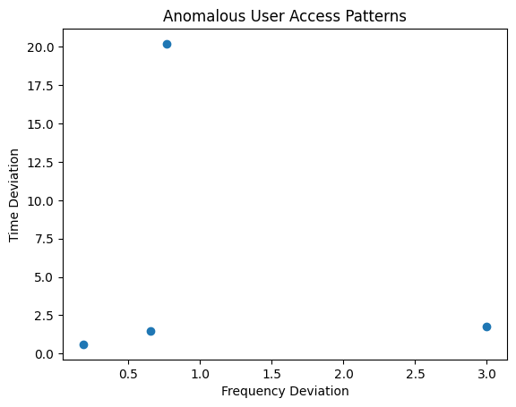

```python
import pandas as pd
import datetime as dt


# 1. Filter data from the past month
end_date = df_Info_data['access_timestamp'].max()

start_date = end_date - pd.Timedelta(weeks=4) # Considering 4 weeks for a month
filtered_data = df_Info_data[(df_Info_data['access_timestamp'] >= start_date) & (df_Info_data['access_timestamp'] <= end_date)]

# 2. Calculate the mean values for each user
mean_values = filtered_data.groupby(['user_id', 'resource_id']).agg(
    mean_access_frequency=('access_frequency', 'mean'),
    mean_access_time=('average_access_time', 'mean')
).reset_index()

# 3. Calculate the deviations for each user
df_Info_data_with_mean = df_Info_data.merge(mean_values, on=['user_id', 'resource_id'], how='left')
df_Info_data_with_mean['freq_deviation'] = abs((df_Info_data_with_mean['access_frequency'] - df_Info_data_with_mean['mean_access_frequency']) / df_Info_data_with_mean['mean_access_frequency'])
df_Info_data_with_mean['time_deviation'] = abs((df_Info_data_with_mean['average_access_time'] - df_Info_data_with_mean['mean_access_time']) / df_Info_data_with_mean['mean_access_time'])

# 4. Filter users with more than 20% deviation
anomalous_users = df_Info_data_with_mean[
    (df_Info_data_with_mean['freq_deviation'] > 0.20) |
    (df_Info_data_with_mean['time_deviation'] > 0.20)
][['user_id', 'resource_id', 'freq_deviation', 'time_deviation']]

print(anomalous_users)

# Plot (optional if you want to visualize the deviations)
import matplotlib.pyplot as plt
plt.scatter(anomalous_users['freq_deviation'], anomalous_users['time_deviation'])
plt.xlabel('Frequency Deviation')
plt.ylabel('Time Deviation')
plt.title('Anomalous User Access Patterns')
plt.show()
```

The results from SQL and python are the same, proving the correctness

## Question 2

**Scenario:** There is a hypothesis that users accessing resources from new or unknown locations or devices might indicate a security breach or at least a reason to be vigilant.

**Question:** From the `location`, `device_signature`, and `previous_breach` columns, can you develop a model to predict the `red_flags` generated by the system? Indicate which feature is the target variable and explain the feature importance.

*Target Variable:* `red_flags`

**Hints**

1. **Data Pre-processing:**
   - Convert categorical features (i.e., `location` and `device_signature`) into numerical representations.
   - Handle any missing values, if present.
2. **Model Selection and Training:**
   - Since `red_flags` is an integer between 0 to 10, this becomes a regression problem. We can use models like Linear Regression, Decision Trees, or Random Forests.
   - For interpretability and feature importance, let's choose a Random Forest Regressor.
3. **Feature Importance:**
   - After training, we can get the feature importance from the Random Forest model to determine which feature contributes the most to the prediction.
4. **Validation:**
   - Use a train-test split or cross-validation to evaluate the model's performance.

```python
# Import necessary libraries
from sklearn.model_selection import train_test_split
from sklearn.preprocessing import LabelEncoder
from sklearn.ensemble import RandomForestRegressor
from sklearn.metrics import mean_squared_error
import matplotlib.pyplot as plt

# Copy the original dataframe
df_Info_data_copy = df_Info_data.copy()

# Convert categorical variables to numerical using Label Encoding on the copied dataframe
le_location = LabelEncoder()
df_Info_data_copy['location_encoded'] = le_location.fit_transform(df_Info_data_copy['location'])

le_device = LabelEncoder()
df_Info_data_copy['device_signature_encoded'] = le_device.fit_transform(df_Info_data_copy['device_signature'])

# Features and Target Variable using the copied dataframe
features = ['location_encoded', 'device_signature_encoded', 'previous_breach']
X = df_Info_data_copy[features]
y = df_Info_data_copy['red_flags']

# Splitting data into training and testing sets
X_train, X_test, y_train, y_test = train_test_split(X, y, test_size=0.2, random_state=42)

# Initializing and training the Random Forest Regressor
rf = RandomForestRegressor(n_estimators=100, random_state=42)
rf.fit(X_train, y_train)

# Predict on Test Data
y_pred = rf.predict(X_test)

# Print RMSE
rmse = mean_squared_error(y_test, y_pred, squared=False)
print(f"Root Mean Squared Error: {rmse}")
```

```
Root Mean Squared Error: 1.0987886511973084
```

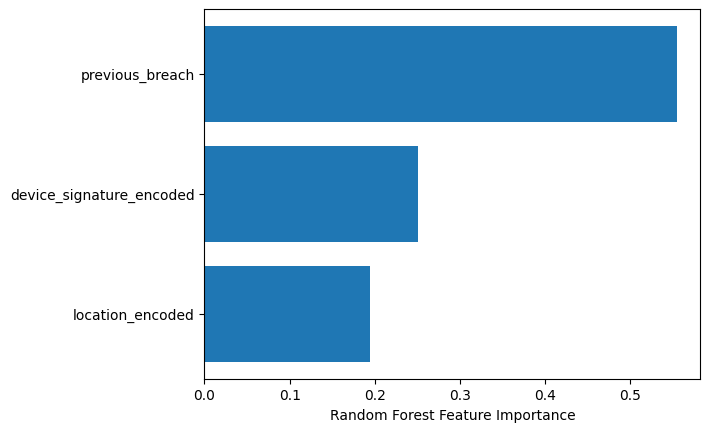

```python
# Plotting Feature Importance
importances = rf.feature_importances_
sorted_idx = importances.argsort()

plt.barh(features, importances[sorted_idx])
plt.xlabel("Random Forest Feature Importance")
plt.show()
```

## Question 3

**Scenario:** Oracle's data resources can have patterns in access types. For example, a write access might commonly be followed by multiple read accesses.

**Question:** Using the `access_type` and `access_timestamp` columns, analyze the sequence of access types in the past week for any unusual patterns not seen in the past six months. (View the latest date in the data as "Today")

**Roadmap for Solution:**

1. **Data Preprocessing and Setup**:
   - Convert `access_timestamp` to datetime format (if it isn't).
   - Sort the data by `access_timestamp` to ensure chronological order.
   - Extract the maximum date from the data as our reference for "Today".
   - Filter the data into two dataframes:
     1. Last week's data.
     2. Past six months' data (excluding the last week).
2. **Pattern Analysis**:
   - Create sequences of access types for each user within the dataframes.
   - Compare the sequences in the last week to the sequences from the past six months. Identify any unusual sequences that appear in the last week but not in the past six months.

```python
# Required Libraries
import pandas as pd

# Assuming df_Info_data is loaded
df_Info_data['access_timestamp'] = pd.to_datetime(df_Info_data['access_timestamp'])
df_Info_data.sort_values(by='access_timestamp', inplace=True)

# Finding 'Today'
latest_date = df_Info_data['access_timestamp'].max()

# Filtering Dataframes for last week and past six months
df_last_week = df_Info_data[(df_Info_data['access_timestamp'] > (latest_date - pd.Timedelta(weeks=1))) &
                            (df_Info_data['access_timestamp'] <= latest_date)]

df_past_six_months = df_Info_data[(df_Info_data['access_timestamp'] > (latest_date - pd.Timedelta(days=182))) &
                                 (df_Info_data['access_timestamp'] <= (latest_date - pd.Timedelta(weeks=1)))]

# Create sequences of access types for each user
def create_sequences(df):
    return df.groupby('user_id')['access_type'].apply(list)

last_week_sequences = create_sequences(df_last_week)
past_six_months_sequences = create_sequences(df_past_six_months)

# Find unusual patterns
unusual_patterns = []

for user, seq in last_week_sequences.items():
    if user in past_six_months_sequences:
        past_seq = past_six_months_sequences[user]

        # Checking sequence pattern in last week is unusual compared to past six months
        if seq not in past_seq:
            unusual_patterns.append((user, seq))

# Display Results
print("Unusual Access Patterns (Last Week vs Past Six Months):\n")
for user, pattern in unusual_patterns:
    print(f"User: {user}, Pattern: {pattern}")

# Comments
if unusual_patterns:
    print("\nThere are some unusual access patterns in the last week compared to the past six months.")
else:
    print("\nNo unusual access patterns were found in the last week compared to the past six months.")
```

```
Unusual Access Patterns (Last Week vs Past Six Months):

User: user_0, Pattern: ['Read']
User: user_10, Pattern: ['Read']
User: user_11, Pattern: ['Read']
User: user_19, Pattern: ['Write']
User: user_2, Pattern: ['Read', 'Write']
User: user_3, Pattern: ['Delete']
User: user_30, Pattern: ['Write']
User: user_33, Pattern: ['Write']
User: user_4, Pattern: ['Write']
User: user_42, Pattern: ['Write']
User: user_46, Pattern: ['Read']
User: user_53, Pattern: ['Read']
User: user_54, Pattern: ['Delete']
User: user_55, Pattern: ['Read']
User: user_57, Pattern: ['Read']
User: user_58, Pattern: ['Write']
User: user_70, Pattern: ['Read']
User: user_80, Pattern: ['Write', 'Delete']
User: user_81, Pattern: ['Write']
User: user_83, Pattern: ['Delete', 'Read']
User: user_88, Pattern: ['Delete', 'Delete']
User: user_95, Pattern: ['Write', 'Delete']

There are some unusual access patterns in the last week compared to the past six months.
```